# Homework 5 - Neural Network and SVM

Nathan Heskia

### Dataset and Objective

The dataset consists of images of hand gestures of the [American Sign Language](https://www.kaggle.com/datamunge/sign-language-mnist).

```r
library(caret)
library(imager)
library(magick)
library(neuralnet)
library(dplyr)
set.seed(311)

signTrain <- read.csv('sign_mnist_train.csv', header = TRUE, stringsAsFactors = FALSE)
signTest <- read.csv('sign_mnist_test.csv', header = TRUE, stringsAsFactors = FALSE)
signTrain$label <- as.factor(signTrain$label)
signTest$label <- as.factor(signTest$label)
```

Each label 0-25 maps to alphabetic letter A-Z. There is no mapping for J and Z. The rest of the columns in each row represent a pixel in a 28 by 28 grayscale image ranging from 0 (black) to 255 (white). Here are some example images from the training set:

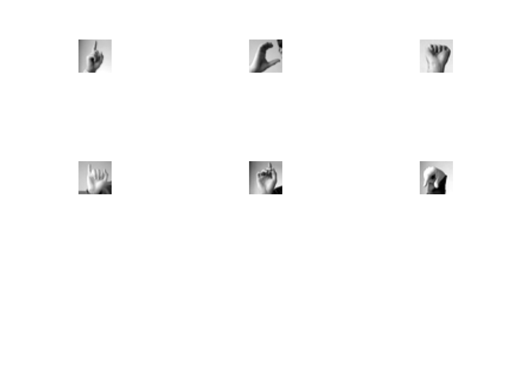

```r
par(mfrow=c(3,3))
plot(magick::image_read(as.cimg(as.numeric(signTrain[1,2:785]))))
plot(magick::image_read(as.cimg(as.numeric(signTrain[3,2:785]))))
plot(magick::image_read(as.cimg(as.numeric(signTrain[2000,2:785]))))
plot(magick::image_read(as.cimg(as.numeric(signTrain[3000,2:785]))))
plot(magick::image_read(as.cimg(as.numeric(signTrain[4000,2:785]))))
plot(magick::image_read(as.cimg(as.numeric(signTrain[5000,2:785]))))
```

```r
signTrain[3,]$label
```

```
## [1] 2
## Levels: 0 1 2 3 4 5 6 7 8 10 11 12 13 14 15 16 17 18 19 20 21 22 23 24
```

The label for middle image in the top row is `2`, meaning this is the gesture for the letter `C`. My objective is to train a classifier that can recognize which letter is represented by the hand gesture in each image and output the corresponding label.

### Preparing the training data

There are over 27,000 rows in the training set. Because of the amount of time this will cause in training the network, I will sample a fixed size of images for each label in the training set and grow the size of the training set based on the results of performance at each step.

```r
# Scale the data between 0 and 1
signTrain[,2:785] <- signTrain[,2:785] / 255
signTest[,2:785] <- signTest[,2:785] / 255

# Take 150 samples for each letter of the alphabet
signTrainSample <- sample_n(signTrain[which(signTrain$label == '0'),], 150)

for(r in c(1:26)) { # J and Z are skipped
  signTrainSample <- rbind(signTrainSample, sample_n(signTrain[which(signTrain$label == as.character(r)),], 150))
}

dim(signTrainSample)
```

```
## [1] 3600  785
```

### Training a Neural Network

I use the `nnet` method from the `caret` package and tune the number of nodes in the hidden layer to 1, 5 and 10.

```r
nnHidden1 <- train(label ~ ., data = signTrainSample, trControl= trainControl(method = "cv", number = 5),
            method = "nnet", tuneGrid = expand.grid(.size = c(1), .decay = 5e-4),
            preProc = c("center", "scale"), linout = 0, trace = FALSE)


nnHidden5 <- train(label ~ ., data = signTrainSample, trControl= trainControl(method = "cv", number = 5),
             method = "nnet", tuneGrid = expand.grid(.size = c(5), .decay = 5e-4),
             preProc = c("center", "scale"), linout = 0, MaxNWts = 4100, trace = FALSE)

nnHidden10 <- train(label ~ ., data = signTrainSample, trControl= trainControl(method = "cv", number = 5),
             method = "nnet", tuneGrid = expand.grid(.size = c(10), .decay = 5e-4),
             preProc = c("center", "scale"), linout = 0, MaxNWts = 8200, trace = FALSE)
```

As the number of nodes in the hidden layer increases, so does the training accuracy and kappa. Let’s apply these models to the testing set, which contains 7172 instances.

```r
hidden1Predict <- predict(nnHidden1, signTest[,-1])
hidden5Predict <- predict(nnHidden5, signTest[,-1])
hidden10Predict <- predict(nnHidden10, signTest[,-1])

hidden1PredictConfMat <- confusionMatrix(hidden1Predict, signTest$label)
hidden5PredictConfMat <- confusionMatrix(hidden5Predict, signTest$label)
hidden10PredictConfMat <- confusionMatrix(hidden10Predict, signTest$label)

hidden1PredictResults <- as.numeric(hidden1PredictConfMat$overall)[1:2]
hidden5PredictResults <- as.numeric(hidden5PredictConfMat$overall)[1:2]
hidden10PredictResults <- as.numeric(hidden10PredictConfMat$overall)[1:2]

resultCombined <- c(
  as.numeric(nnHidden1$results[,-c(1,2)]),
  hidden1PredictResults,
  as.numeric(nnHidden5$results[,-c(1,2)]),
  hidden5PredictResults,
  as.numeric(nnHidden10$results[,-c(1,2)]),
  hidden10PredictResults
)

nnResult <- matrix(resultCombined, ncol=6, byrow=TRUE)
colnames(nnResult) <- c("Train Accuracy","Train Kappa","Train Accuracy SD", "Train Kappa SD", "Test Accuracy", "Test Kappa")
rownames(nnResult) <- c("1","5","10")
nnResult <- as.table(nnResult)
nnResult
```

```
##    Train Accuracy Train Kappa Train Accuracy SD Train Kappa SD Test Accuracy
## 1     0.086388889 0.046666667       0.003011039    0.003141954   0.084634690
## 5     0.429444444 0.404637681       0.023368030    0.024384031   0.381762409
## 10    0.716944444 0.704637681       0.039788697    0.041518641   0.438789738
##     Test Kappa
## 1  0.041617798
## 5  0.353717127
## 10 0.413348022
```

Since our training accuracy is much higher than our test accuracy as the number of nodes increases, this means that our model has **low bias** and **high variance**. In other words, the training process is overfitting the data.

One possible solution to this problem is to increase the size of the training set and run the results for a hidden layer of size 10 to see if accuracy improves.

```r
# Take 250 samples for each letter of the alphabet
signTrainSample <- sample_n(signTrain[which(signTrain$label == '0'),], 250)

for(r in c(1:26)) {
  signTrainSample <- rbind(signTrainSample, sample_n(signTrain[which(signTrain$label == as.character(r)),],250))
}

dim(signTrainSample)
```

```
## [1] 6000  785
```

```r
nnHidden10 <- train(label ~ ., data = signTrainSample, trControl= trainControl(method = "cv", number = 5),
                    method = "nnet", tuneGrid = expand.grid(.size = c(10), .decay = 5e-4),
                    preProc = c("center", "scale"), linout = 0, MaxNWts = 8200, trace = TRUE)
```

```r
hidden10Results <- as.numeric(nnHidden10$results[,-c(1,2)])
hidden10Predict <- predict(nnHidden10, signTest[,-1])
hidden10PredictConfMat <- confusionMatrix(hidden10Predict, signTest$label)
hidden10PredictResults <- as.numeric(hidden10PredictConfMat$overall)[1:2]

nnResult <- matrix(c(hidden10Results, hidden10PredictResults), ncol=6, byrow=TRUE)
colnames(nnResult) <- c("Train Accuracy","Train Kappa","Train Accuracy SD", "Train Kappa SD", "Test Accuracy","Test Kappa")
rownames(nnResult) <- c("10")
nnResult <- as.table(nnResult)
nnResult
```

```
##    Train Accuracy Train Kappa Train Accuracy SD Train Kappa SD Test Accuracy
## 10     0.83783333  0.83078261        0.04381384     0.04571879    0.48326827
##    Test Kappa
## 10 0.46028809
```

One library method which offers a faster training time is `mlpML`, which also enables the network to contain 3 hidden layers of varying size. In the following case, I keep the size of the 3 hidden layers constant and compare the performance of each with a training set containing 400 samples of each letter.

```r
# Take 400 samples for each letter of the alphabet
signTrainSample <- sample_n(signTrain[which(signTrain$label == '0'),], 400)

for(r in c(1:26)) {
  signTrainSample <- rbind(signTrainSample, sample_n(signTrain[which(signTrain$label == as.character(r)),], 400))
}

dim(signTrainSample)
```

```
## [1] 9600  785
```

```r
nnML15 <- train(label ~ ., data = signTrainSample, trControl= trainControl(method = 'cv', number = 5),
                method = 'mlpML', tuneGrid = expand.grid(.layer1 = 15, .layer2 = 15, .layer3 = 15),
                preProc = c('center', 'scale'))

nnML18 <- train(label ~ ., data = signTrainSample, trControl= trainControl(method = 'cv', number = 5),
                method = 'mlpML', tuneGrid = expand.grid(.layer1 = 18, .layer2 = 18, .layer3 = 18),
                preProc = c('center', 'scale'))

nnML20 <- train(label ~ ., data = signTrainSample, trControl= trainControl(method = 'cv', number = 5),
                method = 'mlpML', tuneGrid = expand.grid(.layer1 = 20, .layer2 = 20, .layer3 = 20),
                preProc = c('center', 'scale'))

nnML30 <- train(label ~ ., data = signTrainSample, trControl= trainControl(method = 'cv', number = 5),
                method = 'mlpML', tuneGrid = expand.grid(.layer1 = 30, .layer2 = 30, .layer3 = 30),
                preProc = c('center', 'scale'))

nnML40 <- train(label ~ ., data = signTrainSample, trControl= trainControl(method = 'cv', number = 5),
                method = 'mlpML', tuneGrid = expand.grid(.layer1 = 40, .layer2 = 40, .layer3 = 40),
                preProc = c('center', 'scale'))

nnML54 <- train(label ~ ., data = signTrainSample, trControl= trainControl(method = 'cv', number = 5),
                method = 'mlpML', tuneGrid = expand.grid(.layer1 = 54, .layer2 = 54, .layer3 = 54),
                preProc = c('center', 'scale'))
```

The previous code created 6 different models, each containing 3 hidden layers with a fixed size of 15, 18, 20, 30, 40 and 54 respectively.

```r
nnML15Predict <- predict(nnML15, signTest[,-1])
nnML18Predict <- predict(nnML18, signTest[,-1])
nnML20Predict <- predict(nnML20, signTest[,-1])
nnML30Predict <- predict(nnML30, signTest[,-1])
nnML40Predict <- predict(nnML40, signTest[,-1])
nnML54Predict <- predict(nnML54, signTest[,-1])

nnML15PredictConfMat <- confusionMatrix(nnML15Predict, signTest$label)
nnML18PredictConfMat <- confusionMatrix(nnML18Predict, signTest$label)
nnML20PredictConfMat <- confusionMatrix(nnML20Predict, signTest$label)
nnML30PredictConfMat <- confusionMatrix(nnML30Predict, signTest$label)
nnML40PredictConfMat <- confusionMatrix(nnML40Predict, signTest$label)
nnML54PredictConfMat <- confusionMatrix(nnML54Predict, signTest$label)


nnML15PredictResults <- as.numeric(nnML15PredictConfMat$overall)[1:2]
nnML18PredictResults <- as.numeric(nnML18PredictConfMat$overall)[1:2]
nnML20PredictResults <- as.numeric(nnML20PredictConfMat$overall)[1:2]
nnML30PredictResults <- as.numeric(nnML30PredictConfMat$overall)[1:2]
nnML40PredictResults <- as.numeric(nnML40PredictConfMat$overall)[1:2]
nnML54PredictResults <- as.numeric(nnML54PredictConfMat$overall)[1:2]

resultCombined <- c(
  as.numeric(nnML15$results),
  nnML15PredictResults,
  as.numeric(nnML18$results),
  nnML18PredictResults,
  as.numeric(nnML20$results),
  nnML20PredictResults,
  as.numeric(nnML30$results),
  nnML30PredictResults,
  as.numeric(nnML40$results),
  nnML40PredictResults,
  as.numeric(nnML54$results),
  nnML54PredictResults
)

testMLResult <- matrix(resultCombined, ncol=9, byrow=TRUE)
colnames(testMLResult) <- c(names(nnML15$results), "Test Accuracy", "Test Kappa")
rownames(testMLResult) <- c("15", "18", "20", "30", "40", "54")
testMLResult <- as.table(testMLResult)
testMLResult
```

```
##          layer1       layer2       layer3     Accuracy        Kappa
## 15 15.000000000 15.000000000 15.000000000  0.847604167  0.840978261
## 18 18.000000000 18.000000000 18.000000000  0.891666667  0.886956522
## 20 20.000000000 20.000000000 20.000000000  0.908437500  0.904456522
## 30 30.000000000 30.000000000 30.000000000  0.965208333  0.963695652
## 40 40.000000000 40.000000000 40.000000000  0.973229167  0.972065217
## 54 54.000000000 54.000000000 54.000000000  0.979375000  0.978478261
##      AccuracySD      KappaSD Test Accuracy   Test Kappa
## 15  0.032462585  0.033874002   0.517986615  0.496150716
## 18  0.033602833  0.035063826   0.629531511  0.612866742
## 20  0.032682862  0.034103856   0.626045733  0.608871226
## 30  0.006133904  0.006400596   0.645705521  0.629517559
## 40  0.010022490  0.010458250   0.685303960  0.670905174
## 54  0.007213119  0.007526732   0.711795873  0.698437774
```

The network with 3 hidden layers, each containing 54 nodes, has a training accuracy of 97%. On the test set, this translates to 71% accuracy.

### Trying out the classifier

Let’s try out the classifier on two random images from the test set.

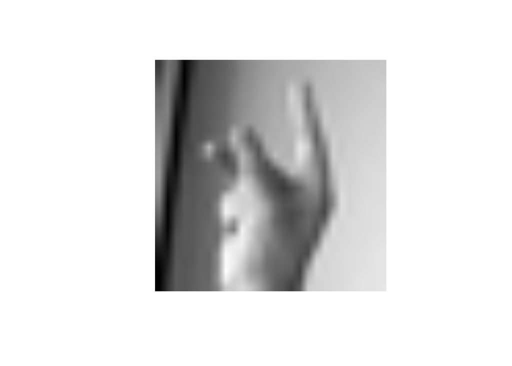

```r
# Get an example image
par(mfrow=c(1,1))
plot(magick::image_read(as.cimg(as.numeric(signTest[750,-1]))))
```

The above is the hand gesture for `K` which should have a label of 10.

```r
prediction <- predict(nnML54, signTest[750,-1])
prediction
```

```
## [1] 24
## Levels: 0 1 2 3 4 5 6 7 8 10 11 12 13 14 15 16 17 18 19 20 21 22 23 24
```

The classifier incorrectly labels this image as 24- which is `Y`:

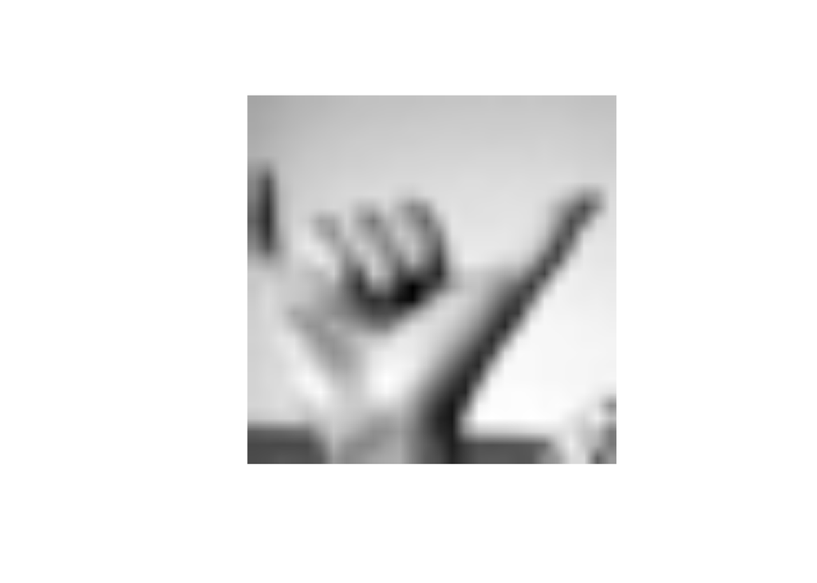

```r
library(dplyr)

yImg <- sample_n(signTest[which(signTest$label == '24'),], 1)
plot(magick::image_read(as.cimg(as.numeric(yImg[,-1]))))
```

Let’s try another label:

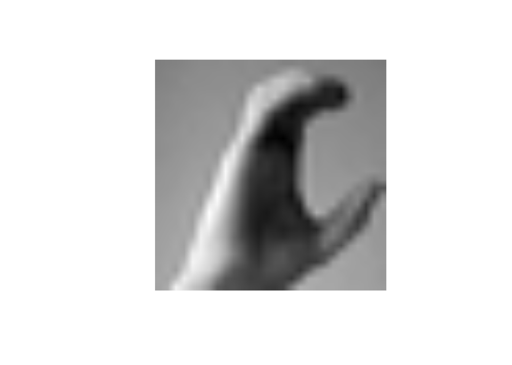

```r
plot(magick::image_read(as.cimg(as.numeric(signTest[700,-1]))))
```

The above image is the hand gesture for `C` which should have a label of 2 (since `A` starts at 0).

```r
prediction <- predict(nnML54, signTest[700,-1])
prediction
```

```
## [1] 2
## Levels: 0 1 2 3 4 5 6 7 8 10 11 12 13 14 15 16 17 18 19 20 21 22 23 24
```

The classifier correctly labeled the image in this case.

This training took several hours. This also suggests that even a nearly perfect model on the training set may still overfit and not perform as well on the test data. This motivated me to look for another model which could increase test accuracy.

### Training a Support Vector Machine

We saw in the previous examples that a neural network tends to increase in accuracy as the number of hidden layers and nodes increases in addition to the size of the training set. The process of training the network is extremely time-consuming. Another option to increase training performance could be to pre-process the images and extract only certain features unique to each sign/letter. In other words, it would be helpful to find a way to segment the images into classes for each sign using the image data. I will attempt to do so using a support vector machine.

```r
# Train on prior 400 samples
sampleSvmModel <- train(label ~ .,data = signTrainSample, trControl = trainControl("cv", number = 10),
                        method = 'svmLinear', preProcess = c('center','scale'))
```

The training process took about 10 minutes. Here are the results:

```r
sampleSvmModel
```

```
## Support Vector Machines with Linear Kernel
##
## 9600 samples
##  784 predictor
##   24 classes: '0', '1', '2', '3', '4', '5', '6', '7', '8', '10', '11', '12', '13', '14', '15', '16', '17', '18', '19', '20', '21', '22', '23', '24'
##
## Pre-processing: centered (784), scaled (784)
## Resampling: Cross-Validated (10 fold)
## Summary of sample sizes: 8640, 8640, 8640, 8640, 8640, 8640, ...
## Resampling results:
##
##   Accuracy  Kappa
##   1         1
##
## Tuning parameter 'C' was held constant at a value of 1
```

In other words, the model has perfectly seperated the data- resulting in a training accuracy of 100%. Using this model on the test set gives the following results:

```r
svmPredict <- predict(sampleSvmModel, signTest[,-1])
confusionMatrix(svmPredict, signTest$label)
```

```
## Confusion Matrix and Statistics
##
##           Reference
## Prediction   0   1   2   3   4   5   6   7   8  10  11  12  13  14  15  16  17
##         0  331   0   0   0   0   0   0   0  26   0   0  16  23   0   0   7   0
##         1    0 411   0   0   0   0   0   0   0   0   0   0   0   0   0   0   0
##         2    0   0 309   0   0  20   0   0   0   0  18   0   4  37   0   0   0
##         3    0   0   0 245   0   0   0   0   0   0   0   0   0   0   0   0   0
##         4    0   0   0   0 498   0   0   2   0   0   0   0   0   0   0   0   0
##         5    0   0   1   0   0 221   0   0   0  40   3   0   0   0   0   0   0
##         6    0   0   0   0   0   0 307  27   0   0   0   0   0   5   0   0   0
##         7    0   0   0   0   0   0   0 402   5   0   0   0   0   0   0   0   0
##         8    0   0   0   0   0   0   0   0 205   0   0   0  10   0   0   0   0
##         10   0   0   0   0   0   0   0   0  10 154   0   0   0   0   0   0   0
##         11   0   0   0   0   0   5   0   0   0   0 167   0   0   0   0   0   0
##         12   0   0   0   0   0   0   0   0   0   0   0 291  25   0   0   0   0
##         13   0   0   0   0   0   0   0   0   0   0   0  21 185  20   0   0   0
##         14   0   0   0   0   0   0   0   0   0   0   0   0  21 168   0   0   0
##         15   0   0   0   0   0   0   0   0   0   0   0   0   0   0 347   0   0
##         16   0   0   0   0   0   0  22   0   0   0   0   0   6   1   0 157   0
##         17   0   0   0   0   0   0   0   0  21  54   0   0   0   0   0   0 101
##         18   0   0   0   0   0   0   0   0   0  21   0  66   0   0   0   0   0
##         19   0   0   0   0   0   1  19   0   0   0   0   0  17  15   0   0   0
##         20   0  21   0   0   0   0   0   5   0  21   0   0   0   0   0   0  20
##         21   0   0   0   0   0   0   0   0   0   0   0   0   0   0   0   0  23
##         22   0   0   0   0   0   0   0   0   0  21   0   0   0   0   0   0   0
##         23   0   0   0   0   0   0   0   0   0   0  21   0   0   0   0   0   0
##         24   0   0   0   0   0   0   0   0  21  20   0   0   0   0   0   0   0
##           Reference
## Prediction  18  19  20  21  22  23  24
##         0    0   0   0   0   0   0   0
##         1    0   0   0   0   0   0   0
##         2    0   0   0   0   0   0   0
##         3    0   3  10   0   0   3   0
##         4   21   0   0   0   0   0   0
##         5    0   0   0  20   0   0   0
##         6    0   0   0   0   0  17   0
##         7    0   5   0   0   0   0   0
##         8   21  15   0   0   0  27  14
##         10   0   0  55  11  20   0   0
```

[output cut: 58 more lines]

```
## Pos Pred Value         0.57874   0.75349   0.57609   0.74830   0.78981
## Neg Pred Value         0.98569   0.98764   0.98448   0.98168   0.98831
## Prevalence             0.03430   0.03458   0.03709   0.04824   0.02872
## Detection Rate         0.02050   0.02259   0.02217   0.03067   0.01729
## Detection Prevalence   0.03542   0.02998   0.03848   0.04099   0.02189
## Balanced Accuracy      0.79106   0.82279   0.79040   0.81250   0.79860
##                      Class: 23 Class: 24
## Sensitivity            0.53933   0.65663
## Specificity            0.99088   0.99401
## Pos Pred Value         0.69565   0.84170
## Neg Pred Value         0.98234   0.98351
## Prevalence             0.03723   0.04629
## Detection Rate         0.02008   0.03040
## Detection Prevalence   0.02886   0.03611
## Balanced Accuracy      0.76510   0.82532
```

The test accuracy is 79%. Still, this is an improvement on the neural network. Because the training accuracy is so high and the time spent training is relatively low, it might be worth it to train on all 27,455 training instances. Since the previous training process only took about 10 minutes, the following process should take half an hour:

```r
# Train on entire training set
svmModel <- train(label ~ ., data = signTrain, trControl = trainControl('cv', number = 10),
                  method = 'svmLinear', preProcess = c('center','scale'))
```

```r
svmModel
```

```
## Support Vector Machines with Linear Kernel
##
## 27455 samples
##   784 predictor
##    24 classes: '0', '1', '2', '3', '4', '5', '6', '7', '8', '10', '11', '12', '13', '14', '15', '16', '17', '18', '19', '20', '21', '22', '23', '24'
##
## Pre-processing: centered (784), scaled (784)
## Resampling: Cross-Validated (10 fold)
## Summary of sample sizes: 24707, 24713, 24709, 24707, 24713, 24707, ...
## Resampling results:
##
##   Accuracy  Kappa
##   1         1
##
## Tuning parameter 'C' was held constant at a value of 1
```

```r
svmPredict <- predict(svmModel, signTest[,-1])
cm <- confusionMatrix(svmPredict, signTest$label)
cm$overall
```

```
##       Accuracy          Kappa  AccuracyLower  AccuracyUpper   AccuracyNull
##      0.8053542      0.7963206      0.7959979      0.8144615      0.0694367
## AccuracyPValue  McnemarPValue
##      0.0000000            NaN
```

The size of the training set did not improve the accuracy on the test set significantly. But we were able to achieve a model with 80% accuracy in a fraction of the time that it took to achieve a lower accuracy with a neural network!